# DATA698_Master_Thesis_Document

Ali Harb, Dilip Ganesan and Raghunathan Ramnath

4/19/2019

# Predict Hospital Readmissions in Diabetes Patients

### Abstract:

Today’s health care is moving towards value based care. With this proposition in mind, CMS (Center for Medicare & Medicaid Services) came up with the concept of Hospital Readmissions Reduction Program (HRRP). This program is a Medicare value-based purchasing program that reduces payments to hospitals with excess readmissions. The program supports the national goal of improving healthcare for Americans by linking payment to the quality of hospital care. Based on this program the Department of Health and Human Services (HHS) reduce the payments to Inpatient Prospective Payment System (IPPS) hospitals for excess readmissions. Some of the diseases that are classified under the excess readmissions are listed below.

1. Acute Myocardial Infarction (AMI)
2. Chronic Obstructive Pulmonary Disease (COPD)
3. Heart Failure (HF)
4. Pneumonia
5. Coronary Artery Bypass Graft (CABG) Surgery
6. Elective Primary Total Hip Arthroplasty and/or Total Knee Arthroplasty (THA/TKA)

As of FY2018, 6 more new disease conditions have got added to the HRRP program, but as of 2018 the HRRP does not consider diabetes mellitus part of the program. Although diabetes is not yet included in the penalty measures, American hospitals spent over $41 billion on diabetic patients who got readmitted within 30 days of discharge in the year 2011.

### Problem Statement:

Predict whether a patient diagnosed with diabetes will be readmitted to hospital within 30 days of discharge.

#### Research Question:

The focus of this research is to answer the following questions.:

1. Is DRG (Diagnosis Related Group) as parameter a positive predictor for hospital readmission in diabetes mellitus patients?
2. What are the strongest predictors that lead to hospital readmission in diabetes mellitus patients?

### Literature Review:

For this project, we have focused our literature review around the parameters that to be used for diabetes hospital readmission prediction. Since our research question is finding the strongest predictor for diabetes hospital readmission, we want to make sure the parameters are qualified for research.

We have grouped the parameters in the data set in to following categories:

##### Patient Demographics (Age, Race and Sex)

##### Payment Methodologies (DRG)

##### Medical Condition and Medications (HbA1C, Insulin and Sulfonylurea et.al)

Let us discuss each of the above in detail below.

##### Patient Demographics:

While starting this research we strongly believe race and sex as the most important predictor for diabetes. According to [Elias K Spanakis et.al] in the U.S., 8.3% of the population or 25.8 million individuals have diabetes. The prevalence of diabetes is highest among Native Americans (33%) and lowest among Alaska natives (5.5%). Non-Hispanic Whites and Asian Americans have similar prevalence rates of 7.1% and 8.4%, respectively, where Non-Hispanic Blacks and Hispanic Americans overall have higher prevalence rates of 11.8% and 12.6%, respectively. In the article, they went even deeper in their analysis stating, among Hispanic Americans, diabetes varied among their countries of origin. South Americans had one of the lowest prevalence rates (10.1 % in men and 9.8% in women). Similarly, low rates were found among Cuban men and women–13.2% and 13.9%, respectively. The prevalence of diabetes was the highest in those of Mexican, Puerto Rican, Central American, and Dominican descent, with rates of 16.2% to 19.3% for men and 18% to 19.4% for women. This holds good even in Asian American race with Asian Indians have the highest diabetes prevalence whereas Koreans and Japanese have the lowest diabetes rates. Another important parameter along with race is the age of the patient. Per [Elias K Spanakis et.al], The prevalence of diabetes was highest in NHWs in the U.S. between the ages of 0-9 and 10-19. NHB children between the ages of 0-9 and 10-19 years have prevalence, where Hispanic American children have high prevalence’s between the ages of 0-9 and 10-19, respectively. All in all, it makes clear that combination of age, race and sex plays a crucial role in diabetes. The above research analysis made us to pick the three parameters for our prediction.

##### Payment Methodologies:

Though many studies have been done on hospital readmission, the parameters that were used are more clinical or patient centric. Though research were made on the dollar impact because of readmission, very less analysis was done on the parameter of how hospitals were reimbursed. This brought us to the important parameter of DRG (Diagnosis Related Group). Hospital admissions are reimbursed based on DRG. [Joseph Futoma et.al] did the comparison of hospital readmission models based on DRG cohorts. For each visit, they have a single Diagnosis Related Group (DRG) code, selected from a set of 815 unique DRGs which break down admissions into broader diagnoses classes than the highly specific ICD codes. They tested a variety of statistical models on 280 different patient-visit cohorts as determined by the DRGs. In the context of regression, this is equivalent to the inclusion of an interaction effect between disease groups and every predictor. According to [M W Rich et. al] there is more financial advantage to hospitals to code patients into more lucrative DRGs, so that patients with more severe disease could conceivably be “promoted” to higher paying DRGs, so the reimbursement increases. From the above research, we feel DRG could be one of the crucial parameter for readmission prediction. Though we do not have the parameter in our dataset, we have got the DRG for the clinical claims data from web scraping.

##### Medical Condition and Medications:

As far as diabetes is concerned, one of the important parameter is H1A1C test, which measures whether a patient is diabetes or prediabetes or normal. According to [Beata Strack et.al] the decision to obtain a measurement of HbA1c for patients with diabetes mellitus is a valuable predictor for readmission. In their analysis, it showed that the profile of readmission differed significantly in patients where HbA1c was checked in the setting of a primary diabetes diagnosis, when compared to those with a primary circulatory disorder. While readmission rates remained the highest for patients with circulatory diagnoses, readmission rates for patients with diabetes appeared to be associated with the decision to test for HbA1c, rather than the values of the HbA1c result. So, the combination of HbA1c along with primary diagnosis plays are very important role in hospital readmission. Along with other medical condition other important factor is the type of medication which was administered to the patient. According to [Pamela C Heaton et al.] administration of SU[Sulfonylurea] drugs to patient with Type 2 diabetes is associated with an 30% increased risk of readmission compared to other drugs. According to [N. J. Wei] Diabetes medical regimen intensification during hospitalization was not associated with early readmission. Among patients with elevated HbA1c, glucose therapy intensification[Insulin] was associated with a decreased 30-day readmission/emergency department admission risk and lower outpatient HbA1c levels.

Apart from the above researched parameters, we also have other parameters which are available as part of clinical data set.

##### Modeling:

Apart from the parameters of the dataset we also did some research on the modeling perspective, [Damian Mingle] has done the hospital readmission modeling based on the Extreme Gradient Boosted Tree. Where in the AUC of the machine learning model in greater than that of the LACE score used by the hospitals to determine hospital readmission risks. We will be using the gradient booster for our analysis. Another interesting approach is the use of deep learning to readmission prediction. Per [Ahmad Hammoudeh et.al] the Convolutional neural networks have provided higher AUC compared to other machine learning algorithms. This is another area of interest we are thinking to explore as part of this research thesis.

### Data Source:

For this research, we used the Health Facts database (Cerner Corporation, Kansas City, MO), a national data warehouse that collects comprehensive clinical records across hospitals throughout the United States. Health Facts is a voluntary program offered to organizations which use the Cerner Electronic Health Record System. The database contains data systematically collected from participating institutions electronic medical records and includes encounter data (emergency, outpatient, and inpatient), provider specialty, demographics (age, sex, and race), diagnoses and in-hospital procedures documented by ICD-9-CM codes, laboratory data, pharmacy data, in-hospital mortality, and hospital characteristics. All data were de identified in compliance with the Health Insurance Portability and Accountability Act of 1996 before being provided to the investigators. The Health Facts data that is used was an extract representing 10 years (1999–2008) of clinical care at 130 hospitals and integrated delivery networks throughout the United States: Midwest (18 hospitals), Northeast (58), South (28), and West (16). Most of the hospitals (78) have bed size between 100 and 499, 38 hospitals have bed size less than 100, and bed size of 14 hospitals is greater than 500. Because this data represents integrated delivery network health systems in addition to stand-alone hospitals, the data contains both inpatient and outpatient data, including emergency department, for the same group of patients. This dataset is available online at UCI Machine Learning Repository.

Along with the clinical claims data set that is available in UCI, we will also be using the diagnosis cross DRG data set that is available in CMS data source and introduce DRG as a parameter in our model. Deriving of appropriate DRG is complicated because it needs lot more claims information than what is available in the UCI data set, so for our analysis we will be deriving a more appropriate DRG for that episode of care.

The most challenging aspect of data collection is getting the DRG data for this dataset. For extraction of DRG data we went with two approaches.

1. The first approach was to use the CMS crosswalk dataset which is more of an approximate DRG value.
2. The next approach is to send the clinical data with requisite parameter and extract the accurate DRG.

We started with the Step 2, the more challenging aspect of data extraction. Normally payer industries use to extract DRG by getting licensed software from different vendors. 3M DRG software is the industry wide solution for getting the DRG. Since using these software costs a lot, we did not want to follow that path. We dig through some research and finally settled on extracting DRG using online Find A Code website.

Find A Code website give DRG when we can send the clinical data online. Some of the clinical data that they require are diagnosis code, patient sex and age. The next problem we stumbled upon is we have 100K rows of record manually submitting the records to the website to extract the DRG was not a feasible task. So, we went in to the route of automated extraction of data set. For this automation, we relied on Selenium/Python(BeautifulSoup) to extract the DRG data.

Selenium is open source automation tool, which helps in submitting the requisite data to a website. We wrote a python code, which will get the input data from xl and go the Find A Code Website and key in the required data in the screen text fields. Once the input data are populated in to those required fields in screen, it automatically goes and click the button get DRG. Once the button is hit on the screen, then the request is send to the server and the Find A Code website does the necessary algorithm to extract the DRG and displays the same in the screen.

Once the DRG is displayed then we used Python(beautifulsoup) package to go the required field and extract the DRG for that input request. Once the DRG was extracted the we wrote the DRG along with the payment for DRG into an output XL file. This process was done in iteration for the entire data set and 100K rows in the data set was filled with DRG and the payment information.

This novel approach not only saved time but also played an important role in the extraction of DRG and in the creation of consolidated data set that is required for this thesis.

### Methodology:

The methodology for addressing the problem statement consist of the following processes: Data Exploration, Data Preparation, Regression Modeling, and Ensemble Method modeling with Decision Tree, Random Forest, Neural Network and XG-Boost. The following are discussed below.

#### Data Exploration:

As a first step in any data analysis, we are going to start with exploration of data set. This step consists of checking whether the variable is numerical or categorical, what is the data type, range of values, plotting to check their distribution, whether are there any NAs and strategy to impute those missing data, how the predictor variables are correlated with one another and with the target variables.

#### Data Preparation:

As a first step for data preparation, we did lot of data munging, we converted clinical data in to values which could be better used for prediction along with development of strategies for handling missing or invalid data values. Our data set contains a certain degree of class bias and to overcome the bias we developed an approach to the separation of the master data set into dedicated regression modeling “Training” and “Test” subsets.

#### Logistic Regression:

Identification, development, and testing of task-appropriate regression models. We used a stepwise subtraction method to build the best possible predictive model include log transformations to better fit the data. The confusion matrix was used to select the “best” model which was based on performance metrics including AIC score, AUC, accuracy, classification error rates, precision, specificity, sensitivity, and F1 scores.

#### Ensemble Method Modeling:

As part of Ensemble methods, we are going to check our prediction using Decision Tree, Random Forest, Neural Network and XG-Boost algorithms to check whether the accuracy of the model goes up or down. Results of all models were then compared to see which of these models could better predict hospital readmission and whether DRG has a role in the readmission or not.

### Data Exploration:

The diabetes dataset we have used consists of 100,000 records and 56 features. Below given is the detailed description of some of the important features in the dataset.

1. Encounter ID: Continuous running number. Provides a unique identifier for each claim record. No NAs
2. Race: Categorical values. Values: African-American, Asian, Caucasian, Hispanic, Other. Very less rows has no data.
3. Gender: Categorical values. Values: Male, Female, Unknown. No NAs
4. Age: Categorical values. Values: Instead of giving unique age ranges because of PHI violation we have age ranges. [0-10), [10-20), [20-30), [30-40), [40-50), [50-60), [60-70), [70-80), [80-90), [90-100). No NAs
5. Weight: Numerical values. Values: Weight of a patient. Almost 90% are NAs. Though as part of Literature review Weight is an important factor, the non availablity of data we are going to not use in our Model
6. Admission type ID: Categorical values. Values: Elective, Emergency, Newborn, Not Available, Not Mapped, Urgent. NAs 7%
7. Discharge disposition ID: Categorical values. Values: 22 levels - Admitted as an inpatient to this hospital, Not Mapped et.al . NAs 4%
8. Admission source ID: Categorical values. Values: 11 levels - Clinic Referral Court/Law, Enforcement, Emergency Room, HMO Referral, Not Available Transfer from another health care facility. NAs 9%
9. Time in hospital: Numerical values. Values: Days spent in the hospital by the patient. NAs 0%
10. Payer code: Categorical values. These does not have much impact on our model from clinical prespective and also almost 50% missing.
11. Medical specialty: Categorical values. These does not have much impact on our model from clinical prespective and also almost 40% missing.
12. Number lab procedures: Numerical values. Values: Number of lab procedures done. No NA
13. Number procedures: Numerical values. Values: Number of procedures done. No NA
14. Number medications: Numerical values. Values: Number of medications prescribed. No NA
15. Number outpatient: Numerical values. Values: Number of outpatient visits by the patient. No NA
16. Number emergency: Numerical values. Values: Number of emergency visits by the patient. No NA
17. Number inpatient: Numerical values. Values: Number of inpatient visits by the patient. No NA
18. Diagnoses 1: Categorical values. Values: Different types of diagnoses referred from the ICD-9 codes 457 Levels. NAs 0.02%
19. Diagnoses 2: Categorical values. Values: Different types of diagnoses referred from the ICD-9 codes 429 Levels. NAs 0.59%
20. Diagnoses 3: Categorical values. Values: Different types of diagnoses referred from the ICD-9 codes 460 Levels. NAs 2.08%
21. Number diagnoses: Numerical values. Values: Number of diagnoses done by the patient. No NAs
22. Max glu serum: Categorical values. Indicates the range of the result or if the test was not taken. Values: >200, >300, Norm and None if not measured. No NAs
23. A1Cresult: Categorical values. Indicates the range of the result or if the test was not taken. Values: >7 (if result was greater than 7%), >8 (if result was greater than 8%), None (if test not taken), and Norm (if result is normal). No NAs
24. 23 features of medications:

    Metformin, Repaglinide, Nateglinide, Chlorpropamide, Glimepiride, Acetohexamide, Glipizide, Glyburide, Tolbutamide, Pioglitazone, Rosiglitazone, Acarbose, Miglitol, Troglitazone, Tolazamide, Examide, Citoglipton, Insulin, Glyburide metformin, Glipizide metformin, Glimepiride pioglitazone, Metformin rosiglitazone, Metformin pioglitazone. Values: Down (if the dosage is reduced), No (if the medicine is not given), Steady (if the dosage is steady), Up (if the dosage is increased). No NAs
25. Change: Categorical values. Values: Ch (if change in medicine), No (if no change in medicine). No NAs
26. Diabetes medicine: Categorical values. Values: No Yes. No NAs
27. Readmitted: Categorical values. Values: FALSE TRUE. No NAs
28. DRG: Categorical values. Values : Different types of Diagnosis Related Group 500 levels: No NAs.
29. DRG Payment: Numerical Values. Values are payment amount for each DRG.

### Data Preparation:

The data set contains total of 56 variables. We investigated each variable did data transformation and picked the variables which are best suited for our modeling. We will look at the variables which were dropped, why we dropped them and variables which went through transformation.

Next, we inspected variable Gender There were three factors with respect to gender, when looked at the data only 3 rows have factor level apart from Male and Female. We dropped those 3 rows, it will not affect our model dropping those 3 rows. Other variable with patient population which is important is Race. We collapsed race in to following categories (1- Other, 2 - African American, 3 - Asian, 4- Caucasian, 5 - Hispanic). The other variable Age which was in a set of ranges of values, instead of age range we took average of age range and used the average to replace the age range.

From data perspective, we looked at unique Discharge values in data set. There were four data values which were related to Death of patient in the hospital. Since a person dying in hospital has no chance of getting re admitted, we dropped those rows. On analysis of medications, we figured Examide and Citoglipton was not administered to the entire patient population. So, it is of no use to add these two in our analysis and it was decided to drop.

Some of the variables were in we changed from Yes/No to 1/0. Those variables are Readmitted, Change of Medication, Diabetes Medication, Hb1AC Test Result, Max Glu Serum.

After removing most of the variables our final data set contains 30 variables including DRG.

Next, we want to see the plot of the variables in our data set. From the plots we can see the following variables are skewed. DRGClassification, Age, Time in Hospital, Number of Medications. To correct for the skewness, we will be performing a Log Transformation on these variables during our modeling.

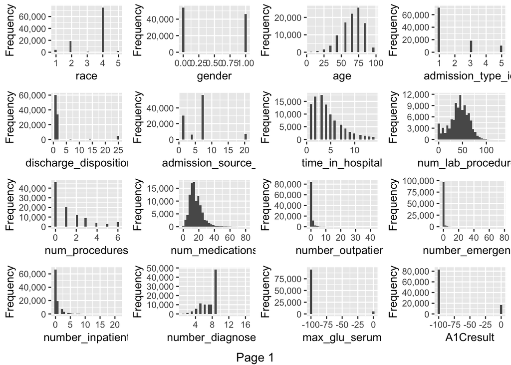

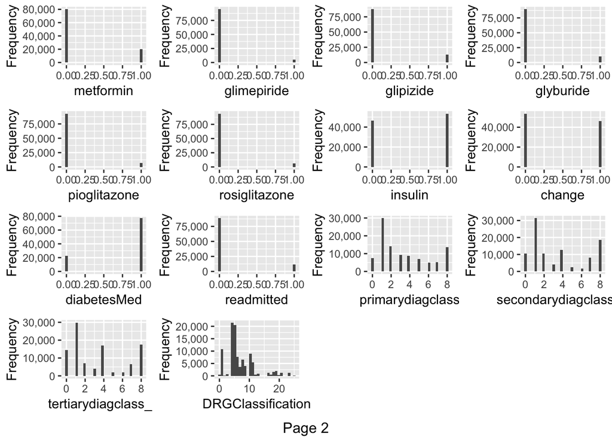

We also wanted to check the Correlation of predictor variables and between predictor and response variables. From the below plot we see positive correlation between 1. DiabetesMed and MedicationChange, 2.MedicationChange and Insulin, 3. Max_Glu_Serum and Admission_Type, 4. Number of Medication and Time in Hospital. Though we see some negative correlation between variables, they are not so profound. As part of Regression analysis, we will perform Variance Inflation Factor to check for Multicollinearity.

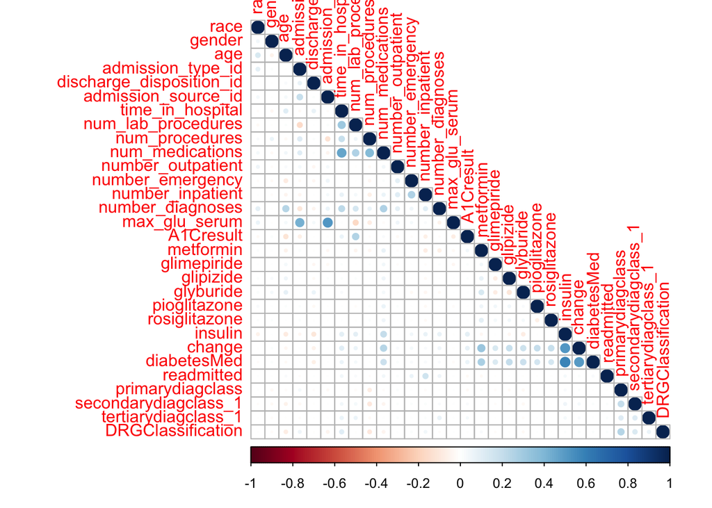

#### Training and Test Data for Logistic Regression:

As a first step in data preprocessing, splitting of training and test data set, is to check the class bias. In our dataset, there is class bias in our target variable

Ideally, the proportion of events and non-events in the target variable should approximately be the same. So, lets first check the proportion of classes in the dependent variable readmitted.

| Var1 | Freq |
| --- | --- |
| 0 | 88603 |
| 1 | 11347 |

Clearly, there is a class bias, a condition observed when the proportion of events is much smaller than proportion of non-events. So, we must sample the observations in approximately equal proportions to get better models.

As a next step, we are going through the process to remove class bias.

One way to address the problem of class bias is to draw the 0s and 1s for the trainingData in equal proportions. In doing so, we will put rest of the input Data not included for training into testData. As a result, the size of trainingData sample will be smaller that validation. This is better than having the model go wrong.

Once the trainingData and testData are created from our dataset, the next step is to create the Binary Logistic Regression.

### Logistic Regression:

#### Binary Regression Base Model

As first step, we are going to run our model using all the variables that are available in the data set. This includes DRGClassification also as predictor variable.

##### Summary

Analysis of coefficients of Base Model.

|  | Estimate | Std. Error | z value | Pr(>\|z\|) |
| --- | --- | --- | --- | --- |
| (Intercept) | -1.2471730 | 0.1678836 | -7.4287966 | 0.0000000 |
| race | -0.0165265 | 0.0181249 | -0.9118155 | 0.3618659 |
| gender | 0.0229196 | 0.0332869 | 0.6885477 | 0.4911080 |
| age | 0.0062533 | 0.0011351 | 5.5088909 | 0.0000000 |
| admission_type_id | -0.0148371 | 0.0146160 | -1.0151232 | 0.3100471 |
| discharge_disposition_id | 0.0032313 | 0.0031603 | 1.0224700 | 0.3065585 |
| admission_source_id | -0.0098438 | 0.0042409 | -2.3211565 | 0.0202784 |
| time_in_hospital | 0.0188556 | 0.0066201 | 2.8482519 | 0.0043960 |
| num_lab_procedures | 0.0008208 | 0.0009627 | 0.8525895 | 0.3938870 |
| num_procedures | -0.0180566 | 0.0111157 | -1.6244183 | 0.1042866 |
| num_medications | 0.0074724 | 0.0027006 | 2.7670007 | 0.0056575 |
| number_outpatient | -0.0140258 | 0.0125846 | -1.1145217 | 0.2650554 |
| number_emergency | 0.0712899 | 0.0208360 | 3.4214712 | 0.0006228 |
| number_inpatient | 0.3123913 | 0.0140707 | 22.2015559 | 0.0000000 |
| number_diagnoses | 0.0569270 | 0.0097778 | 5.8220696 | 0.0000000 |
| max_glu_serum | 0.0026733 | 0.0009683 | 2.7609185 | 0.0057639 |
| A1Cresult | -0.0011097 | 0.0004718 | -2.3521231 | 0.0186666 |
| metformin | -0.1697504 | 0.0479709 | -3.5386140 | 0.0004022 |
| glimepiride | -0.1426876 | 0.0802128 | -1.7788630 | 0.0752622 |
| glipizide | -0.0394206 | 0.0554962 | -0.7103303 | 0.4774993 |
| glyburide | -0.0770857 | 0.0612274 | -1.2590069 | 0.2080278 |
| pioglitazone | -0.1051970 | 0.0673396 | -1.5621858 | 0.1182442 |
| rosiglitazone | -0.0701111 | 0.0705504 | -0.9937734 | 0.3203332 |
| insulin | -0.0369879 | 0.0535855 | -0.6902590 | 0.4900313 |
| change | 0.0647218 | 0.0474893 | 1.3628710 | 0.1729232 |
| diabetesMed | 0.2325196 | 0.0597013 | 3.8947149 | 0.0000983 |
| primarydiagclass | -0.0154751 | 0.0066070 | -2.3422168 | 0.0191696 |
| secondarydiagclass_1 | 0.0079339 | 0.0058183 | 1.3635954 | 0.1726950 |
| tertiarydiagclass_1 | 0.0175397 | 0.0057634 | 3.0432966 | 0.0023400 |
| DRGClassification | 0.0044458 | 0.0036723 | 1.2106434 | 0.2260321 |

##### Optimal CutOff:

The default cutoff prediction probability score is 0.5 or the ratio of 1’s and 0’s in the training data. But sometimes, tuning the probability cutoff can improve the accuracy in both the training and test dataset. The optimal cutoff is used to improve the prediction of 1’s, 0’s, both 1’s and 0’s and to reduce the misclassification error. Below we will compute the optimal score that we use to minimize the misclassification error for the model. The optimal cutoff value for our model 0.998445

#### VIF:

From our corrplot analysis we did not find much correlation between our predictor variables and between predictor variable and target variable. Further as next step in our regression analysis, we want to confirm the same by validating the variance inflation factor. We should check for multicollinearity in the model. As seen below, all predictor variables in the model have VIF well below 4.

|  | x |
| --- | --- |
| race | 1.051333 |
| gender | 1.020962 |
| age | 1.163690 |
| admission_type_id | 1.390994 |
| discharge_disposition_id | 1.037087 |
| admission_source_id | 1.421390 |
| time_in_hospital | 1.448778 |
| num_lab_procedures | 1.298425 |
| num_procedures | 1.290099 |
| num_medications | 1.746123 |
| number_outpatient | 1.035940 |
| number_emergency | 1.096536 |
| number_inpatient | 1.111531 |
| number_diagnoses | 1.223003 |
| max_glu_serum | 1.719808 |
| A1Cresult | 1.110510 |
| metformin | 1.304300 |
| glimepiride | 1.110022 |
| glipizide | 1.292438 |
| glyburide | 1.297341 |
| pioglitazone | 1.109716 |
| rosiglitazone | 1.100765 |
| insulin | 2.636983 |
| change | 2.087960 |
| diabetesMed | 2.226846 |
| primarydiagclass | 1.117049 |
| secondarydiagclass_1 | 1.073137 |
| tertiarydiagclass_1 | 1.035312 |
| DRGClassification | 1.115241 |

#### ROC:

Receiver Operating Characteristics Curve traces the percentage of true positives accurately predicted by a given logit model as the prediction probability cutoff is lowered from 1 to 0. For a good model, as the cutoff is lowered, it should mark more of actual 1’s as positives and lesser of actual 0’s as 1’s. So for a good model, the curve should rise steeply, indicating that the TPR (Y-Axis) increases faster than the FPR (X-Axis) as the cutoff score decreases. Greater the area under the ROC curve, better the predictive ability of the model. We will not look at the curve for our model. From the below curve we can see our curve with AUROC value of 0.625. The value is decent value, though not good.

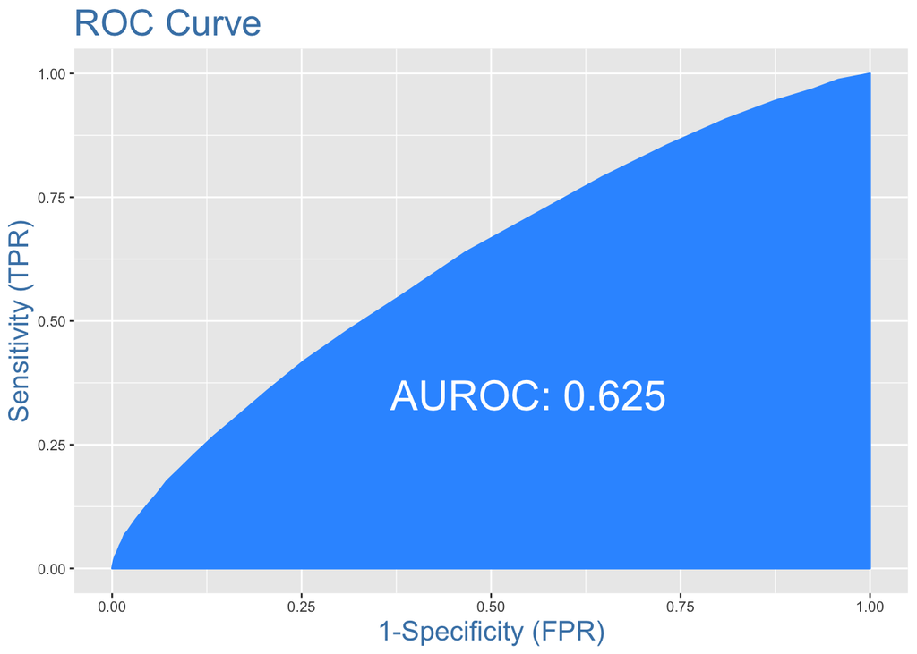

From the confusion Matrix analysis, we concluded that our model Accuracy is 67.8752409%. We can predict with 67.8752409% accuracy that with DRG as a predictor variable the diabetic mellitus patient will get readmitted. When you look at the Sensitivity of our model it is good. Sensitivity (or True Positive Rate) is the percentage of 1’s (actuals) correctly predicted by the model. Which is what we are looking for in our readmission analysis.

#### Binary Regression Base With Reduced Predictors:

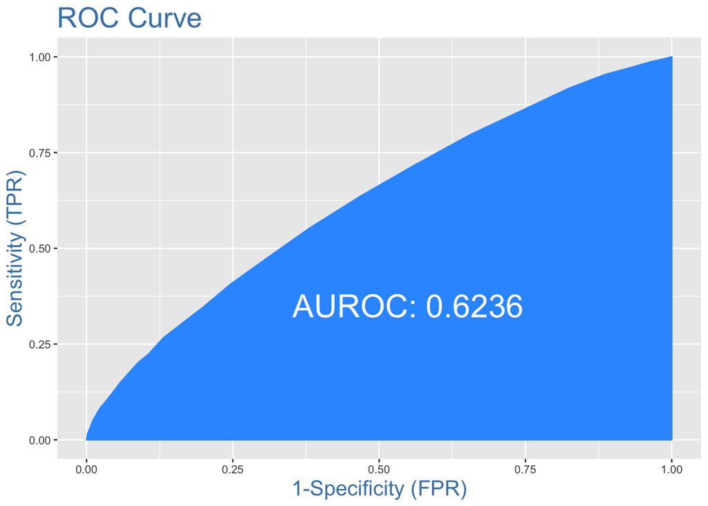

From our reduced predictor variable regression model, the Accuracy of our model has gone up, though not by a greater percent, but to some degree to a value of 68.479528% . This shows that DRGClassification acts a negative parameter from logistic regression modelling perspective. We would like to see how the other logistic regression and ensemble models before drawing conclusions.

#### Binary Regression Base With Log transformation:

From the plots in our data preparation step, we found some of the variables are skewed either to the left or right. Out of those parameters, the parameters which are important to us as part of our Literature review are Age, Time_In_Hospital and DRGClassification. So, in our base model we want to do a log transformation on these parameters and see whether the accuracy our model increases.

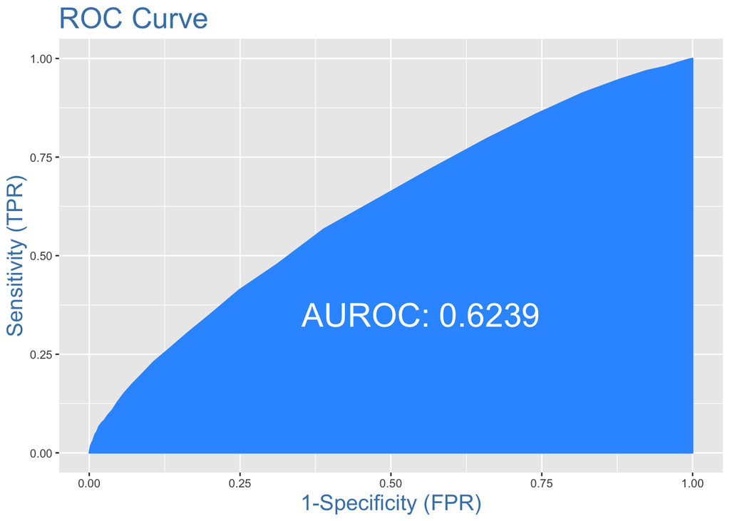

For the final model with log transformed variables, the accuracy of the model is 67.9133062%

### Conclusion for Binary Logistic Regression:

Comparing the accuracy of the three logistic regression accuracy, the model without DRG had a better accuracy compared to the one with DRG by a smaller margin. So we can conclude that the DRG is not a huge factor in hospital readmission rate for diabetic mellitus patients. Having said that including DRG in the model does not decreases the accuracy by greater margin. So, it is more of a neutral effect. Below is the accuracy chart of three models.

| Model_Name | Accuracy | ClassErrorRate | Precision | Senstivity | Specificity | F1 |
| --- | --- | --- | --- | --- | --- | --- |
| Model with DRG | 67.87524 | 0.3212476 | 0.6870111 | 0.9692173 | 0.0611729 | 0.8040715 |
| Model No DRG | 68.47953 | 0.3152047 | 0.6937801 | 0.9688707 | 0.0610864 | 0.8085681 |
| Model Log Trans Var | 67.91331 | 0.3208669 | 0.6875690 | 0.9690214 | 0.0608206 | 0.8043860 |

### Ensemble Method and Other Modelling:

#### Decision Tree:

The machine learning behind this method is to figure out which variable and which threshold to use at every split. One advantage of tree-based methods is that they have no assumptions about the structure of the data and can pick up non-linear effects if given sufficient tree depth. We can fit decision trees using our cleaned-up data that has 30 predictor variables.

For analysis on decision tree, we ran the model with DRG as a parameter and another model without DRG as parameter. The accuracy of the model with DRG and without DRG did not make big difference. 0.6777413

Comparing the Variable importance for both the model with DRG and without DRG, the DRGClassifier was of one of the importance parameter.

#### Random Forest:

Before getting in depth about Random Forest, one of the most common issue with Decision Tree model is overfitting. Overfitting is a statistical modeling error that contains more parameters than can be justified by the data. In other words, the essence of overfitting is to have extracted some of the residual variation (i.e. the noise) as if that variation represented underlying model structure. To overcome the problem of Overfitting, we use go for Random Forest. A random forest allows us to determine the most important predictors across the explanatory variables by generating many decision trees and then ranking the variables by importance.

We are going to use the randomforest package to perform our modeling. We are going to do the modeling on the base data set and see whether DRG is one of the important variable in the bagging process. In other words, we are using Random Forest to find what are the importance variables for effective prediction. We are running our model with 100 trees. Summary of the model can be seen below.

```r
#Summary of the model
print(model.rf)
```

```
##
## Call:
##  randomForest(formula = readmitted ~ ., data = randtrainingData,      ntree = 100, mtry = 8, importance = T, proximity = T, na.action = na.exclude)
##                Type of random forest: classification
##                      Number of trees: 100
## No. of variables tried at each split: 8
##
##         OOB estimate of  error rate: 40.51%
## Confusion matrix:
##      0    1 class.error
## 0 4766 3176   0.3998993
## 1 3259 4683   0.4103500
```

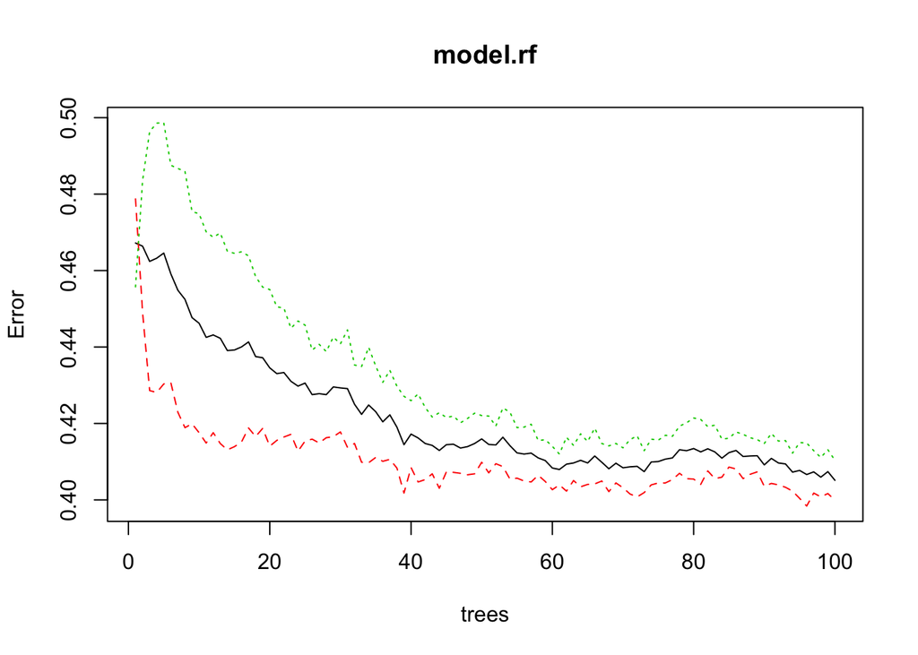

[figure not shown]

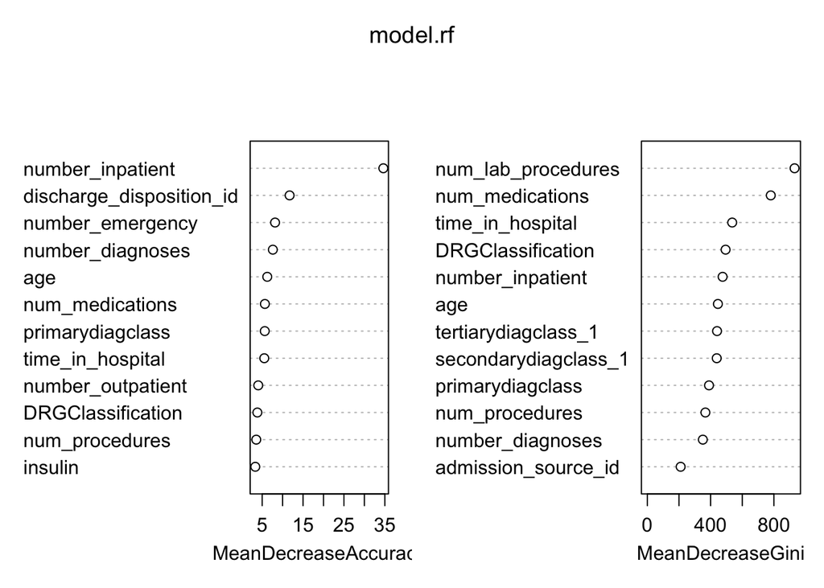

#### Neural Network:

Neural networks are built from units called perceptrons (ptrons). Ptrons have one or more inputs, an activation function and an output. An ANN model is built up by combining ptrons in structured layers. The ptrons in a given layer are independent of each other, but the each connect to all the ptrons in the next layer.

The input layer contains a ptron for each predictor variable. One or more hidden layers contain a user defined number of ptrons. Each ptron in the first hidden layer receives an input from the each ptron in the input layer. The output layer contains a ptron for each response variable. Each output ptron receives one input from each ptron in the hidden layer. The ptrons have a nonlinear activation function (e.g a logistic function) which determines their output value based upon the values of their inputs.The connections between ptrons are weighted. The magnitude of the weight controls the strength of the influence of that input on the receiving ptron. The sign of the weight controls whether the influence is stimulating or inhibiting the signal to the next layer.

In our analysis, we are going to check the accuracy of our prediction and variables which are important for our prediction. Below we the accuracy of our model is 0.7183285.

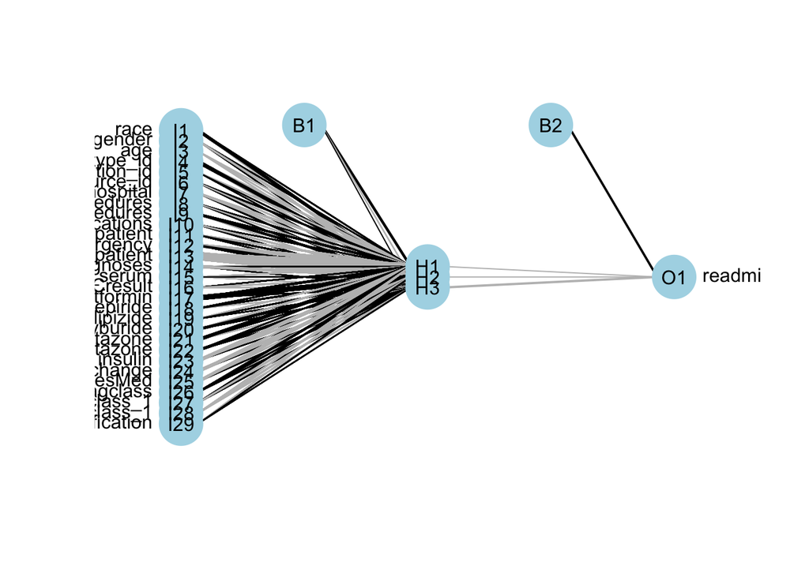

[figure not shown]

##### Neural Network using SMOTE

The Sampling method utilizes the SMOTE algorithm which an oversampling method based on synthetic minority oversampling technique uses k-nearest neighbors to create synthetic examples of the minority class. It injects the SMOTE method at each iteration. The advantage of this approach is that while standard boosting gives equal weights to misclassified data, SMOTE gives more examples of the minority class at each boosting step. The model produces and highly correlated result with 92 % accuracy. This result is confirmed by the high precision of 87% and 99% of recall.

The link can be found at below location : https://github.com/dilipganesan/DATA698/blob/master/Neural%20netwok/NeuralNetwork.pdf

#### XGBoost:

XG Boost Algorithm: XGBoost is a library designed and optimized for boosting trees algorithms. Gradient boosting trees model is originally proposed by Friedman et al. The underlying algorithm of XGBoost is similar to the classic gbm algorithm. By employing multi-threads and imposing regularization, XGBoost can use more computational power and get more accurate prediction.

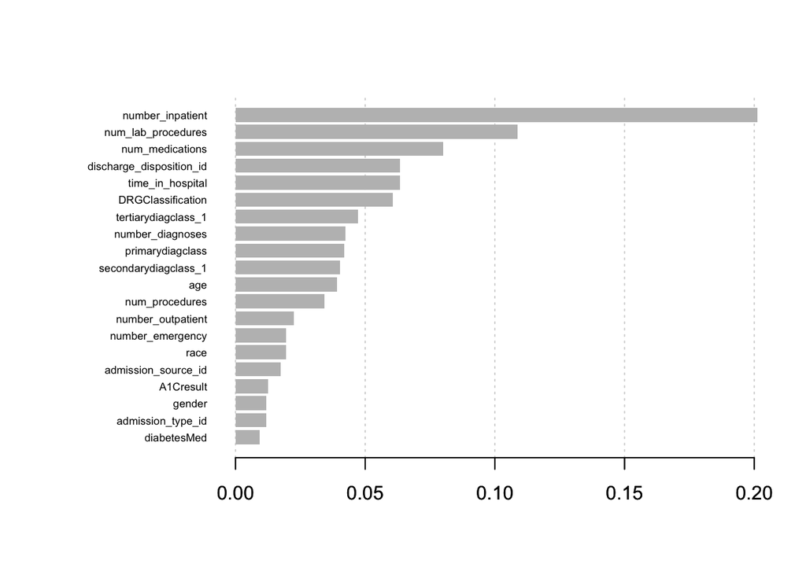

We used the package XGBoost to go about with the model and prediction. The first step in XGBoost model is that it accepts only numeric variables, so a part of preprocessing we converted our factors to numeric value. We use One hot encoding process to convert the categorical to numeric. Next the model has own way of accepting the train and test data sets. The train and test data set needs to in Matrix format. The Dmatrix format is used to convert the train and test data set. The next step in the process is cross validation. It is used to calculate the best nround for this model. The lowest error was achieved at 6th iteration. Which we felt it to be much lower, so we did the trained the model at 50 iterations. The CV error minimum value is 0.34 with a CV accuracy of 66%. We will have to check out test set accuracy and determine if this makes sense. The objective function binary:logistic returns output probabilities rather than labels. To convert it, we need to manually use a cutoff value. We have used 0.5 as my cutoff value for predictions.

Accuracy of XGBoost Model is 0.598387 and the Variable Importance Plot is visualized. From the plot, it is clear that the DRG classifier is at the top 6 important variables in our prediction model. So, we can conclude that the DRG plays a significant role in the prediction of hospital readmission.

### Conclusion and Next Steps:

#### Accuracy Comparison of Models

| Model | Accuracy |
| --- | --- |
| Binary Log DRG | 67.875240882164 |
| Binary Log No-DRG | 68.4795279899127 |
| Binary Log Trans Var | 67.913306211786 |
| Decision Tree | 67.7741298503557 |
| Random Forest | 60.2966716627412 |
| Neural Network | 71.8328456212976 |
| Neural Network using SMOTE | 92.69975463 |
| XG Boost | 59.8386981657269 |

We started this thesis with following problem statement in mind.

1. Is DRG (Diagnosis Related Group) as parameter a positive predictor for hospital readmission in diabetes mellitus patients?
2. What are the strongest predictors that lead to hospital readmission in diabetes mellitus patients?

To achieve the end goal, we started with the following steps. First we started with gathering of data, our dataset did not contain DRG variable which is crucial for our analysis. So, in data gathering phase we did automated scripting to fetch the DRG from the website Find A Code. For fetching the DRG we used variable in clinical dataset like diagnosis codes, patient age and sex. Once we extracted the DRG for each encounter data, we cross mapped them to DRG Classification code, since having 500 separate DRG will not add much value in prediction.

Once the consolidate dataset was prepared with 56 variables including DRG and DRG Final Paid Amount, we followed with investigating the variables and dataset. We removed variables which had more than 50% NAs data, we removed medication variables which had class imbalance, we also looked the dataset from clinical perspective and removed variables and data which does not make clinical significance. The total variables narrowed down for our modeling came down to 30. From plotting of frequency, we discovered some variables have skewness and the strategy was to perform log transformation to correct the skewness. We also did a correlation analysis to make sure we do not run into the problem of multicollinearity.

Next preparation of training and test dataset, since our dataset had class bias on the target(readmitted) variable, we extracted 1s and 0s data for training dataset in right proportion. Once the training and test data were prepared, the next step was to perform predictive modelling. We started with Binary Logistic regression for our dataset. Our strategy for Logistic regression is to run the model with base variables and data and see how the model behaves, followed by running the model without DRG and other variables which does not add much significance to see whether the accuracy of the model goes up or down and finally to run the model with log transformed variables which had skewness. The accuracy, AUC and other parameters of three models are listed above.From the above analysis we see not much difference in accuracy of all the three models. Even though model with significant variables has a better accuracy, the difference is not that significant to conclude the model is the best. From this we can say that the DRG is a neutral variable in terms of accuracy of binary logistic model. Next, we did comparison of accuracy using Decision Tree, Random Forest, Neural Network and XGBoost. From the accuracy chart, we see Neural Network has better accuracy followed by Decision Tree. The Bagging/Boosting algorithms of Random Forest and XGBoost did not resulted in greater accuracy to much of our disappointment. We see more scope for improvement in these two models.

In probing the next question of strongest predictor variables, we see the following variables has impact on the model. Some of the variables are Number of Lab procedures (If the number of procedures are more, then it means that patient could be suffering from more complications), Discharge Disposition (Patients with Discharge disposition of “Left Against Medical Advise” has higher chance of getting readmitted ), Number of Medications, time in hospital et.al. The one parameter which stood out was DRGClassification. In both the Random Forest and XGBoost variable importance plot it stood out one among top 6, playing a very significant predictor. This we consider as a big success to our thesis because all the researches done so far never considered DRG to be a variable in their dataset. Having discovered the variable is of top significance in predicting the readmission of Diabetes patient warrants us to probe DRG much deeper in future analysis. From this we can conclude that DRG acts as an important parameter in hospital readmission of patients.

As for next step, we wanted to see a pattern in how the hospitals are using DRG and the amounts they get reimbursed for these DRGs. Future research needs to be done to see a pattern in the DRG billing. Apriori algorithms of sort can be used for frequent item set mining and association rule learning over transactional clinical datasets. Also, to improve the accuracy of Random Forest and XGBoost, we would like to change the clinical dataset by including some parameter which has better scope in increasing accuracy.

#### References

1. https://bmcendocrdisord.biomedcentral.com/articles/10.1186/s12902-016-0084-z
2. https://www.sciencedirect.com/science/article/pii/S1532046415000969#t0005
3. https://www.ncbi.nlm.nih.gov/pmc/articles/PMC3552066/
4. https://www.sciencedirect.com/science/article/pii/S1877050918317873
5. https://www.researchgate.net/publication/315640596_Predicting_Diabetic_Readmission_Rates_Moving_Beyond_HbA1c
6. https://www.hindawi.com/journals/bmri/2014/781670/
7. https://www.ncbi.nlm.nih.gov/pmc/articles/PMC1350282/?page=3
8. https://clindiabetesendo.biomedcentral.com/articles/10.1186/s40842-016-0040-x
9. https://www.ncbi.nlm.nih.gov/pmc/articles/PMC4439931/
10. https://www.mdmag.com/medical-news/patients-with-diabetes-often-readmitted-for-hypo-and-hyperglycemia
11. https://link.springer.com/article/10.1007/s11892-018-0989-1
12. https://www.healthleadersmedia.com/clinical-care/diabetes-complications-increase-readmission-risk

#### Appendix

The final code deliverable is available in the following location:

https://github.com/dilipganesan/DATA698/tree/master/Final

The entire code base is available in the following location:

https://github.com/dilipganesan/DATA698

Youtube Link : https://youtu.be/gaKZxE_nRGw